# IMX-USD

## IMX-USD today is +0300, 2025-07-15, 12:09:20

This crypto forecast was generated by gemini-2.0-flash API

## Daily Chart

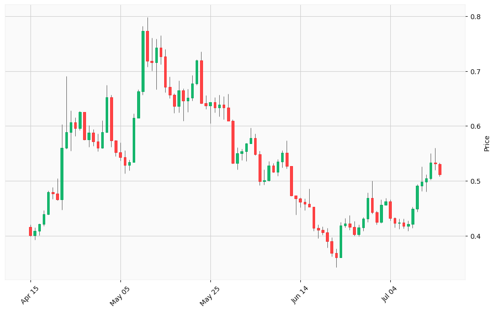

## Hourly Chart

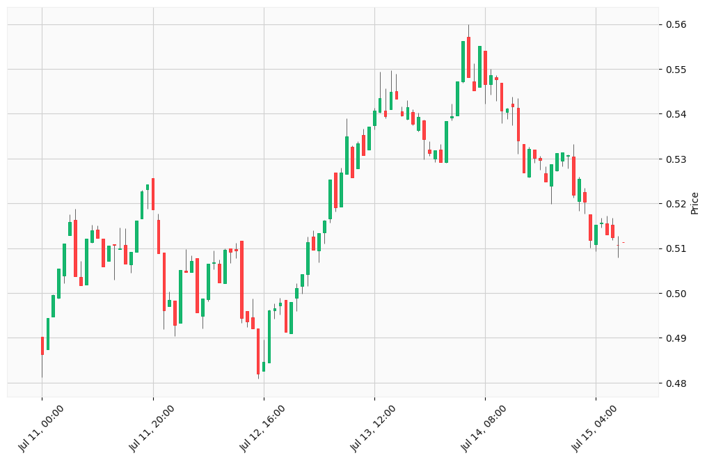

Okay, I will analyze the provided IMX-USD charts and generate trading signals based on technical and news analysis, while also considering broader market scenarios. I will use the format you specified for the output.

First, I’ll collect general information about IMX-USD to understand the project and any recent news that might affect the analysis.

- **Immutable X (IMX)**: It is a layer-2 scaling solution for NFTs on Ethereum, designed to provide faster, more efficient, and less expensive transactions, especially for blockchain gaming. It utilizes zk-rollups technology.
- **IMX Token**: The native token of the Immutable X platform. It is used for paying transaction fees, staking, and governance.
- **Market Position**: Immutable X aims to be a leading platform for NFT trading and web3 gaming.
- **Competition**: Faces competition from other NFT projects and layer-2 solutions.
- **Regulatory Landscape:** The U.S. SEC closed its investigation in 2024 viewing IMX as a token, not a security.

Now, let’s proceed with the technical analysis of the provided data.

**1. Daily Chart Analysis (Last Three Months):**

First, let’s calculate some basic technical indicators from the daily chart data:

- **Simple Moving Average (SMA):** I’ll calculate the 20-day SMA to identify the general trend.
- **Relative Strength Index (RSI):** I’ll calculate the 14-day RSI to identify overbought or oversold conditions.

Here’s a Python code snippet to do that.

```python
import pandas as pd
import numpy as np

# Daily OHLCV data
daily_data = """
0.415599,0.420802,0.399104,0.400885,28703608
0.400885,0.4152,0.392772,0.408705,29679763
0.408705,0.422432,0.400892,0.421524,26955341
0.421524,0.446326,0.41744,0.438844,35102960
0.438844,0.48218,0.438226,0.479606,55970315
0.479606,0.488317,0.467124,0.476725,43087953
0.476725,0.504404,0.464076,0.466406,48173367
0.466405,0.603049,0.446992,0.559619,196479352
0.559619,0.690801,0.558063,0.588409,430449157
0.588409,0.627984,0.554559,0.606451,132086736
0.606451,0.615087,0.581656,0.596139,66552006
0.596173,0.627537,0.592275,0.624954,49210734
0.624954,0.624958,0.574633,0.575206,33946528
0.575216,0.601084,0.561384,0.587636,36072835
0.587636,0.59423,0.564013,0.571695,33911270
0.571695,0.585906,0.553464,0.559624,35524417
0.559625,0.60973,0.559281,0.588269,48533437
0.588295,0.674801,0.587763,0.652555,181094196
0.652555,0.656517,0.56163,0.573841,60197762
0.573841,0.57409,0.544456,0.551798,32948034
0.551804,0.569865,0.53636,0.542886,35837325
0.542886,0.555742,0.513563,0.529074,41988193
0.529069,0.538955,0.51923,0.534487,38414390
0.534486,0.622289,0.534482,0.614728,63206373
0.614745,0.666589,0.614741,0.662599,76229536
0.662599,0.781985,0.656288,0.77287,77809599
0.772873,0.798066,0.707908,0.718539,74813628
0.71854,0.760358,0.700189,0.715537,92881295
0.715537,0.75862,0.666783,0.742391,61343297
0.742332,0.76525,0.711848,0.726739,58676385
0.726739,0.739509,0.661037,0.670772,56998219
0.670854,0.689941,0.650446,0.656302,40103665
0.656302,0.65945,0.623633,0.636269,34372437
0.636269,0.68263,0.624129,0.664566,38759799
0.664566,0.668679,0.609317,0.645665,38051244
0.645665,0.667627,0.625549,0.651568,32611752
0.651568,0.692062,0.645803,0.677111,45205952
0.677111,0.72106,0.674274,0.719463,41177023
0.719469,0.735013,0.640601,0.641745,49911226
0.641745,0.655435,0.630638,0.636606,27553298
0.636606,0.642984,0.604591,0.642935,26649952
0.642935,0.652257,0.624227,0.633055,34315917
0.633055,0.656627,0.617313,0.639202,33165152
0.639202,0.654077,0.612362,0.633369,30946216
0.633396,0.658729,0.609137,0.609259,31094585
0.609257,0.611518,0.531783,0.532203,47526745
0.532203,0.560843,0.520235,0.550142,38319716
0.550142,0.557976,0.537385,0.553717,25247540
0.553718,0.569071,0.53558,0.567718,25179059
0.567718,0.596693,0.567717,0.577709,32702820
0.577709,0.586148,0.546433,0.548379,23522470
0.548379,0.554632,0.49198,0.499109,33191298
0.499109,0.520704,0.492679,0.501231,32166241
0.501227,0.535447,0.499369,0.527607,23365547
0.527607,0.532485,0.515165,0.516602,24945571
0.516602,0.53981,0.509114,0.535417,33117540
0.535417,0.555151,0.524022,0.551376,49662166
0.551376,0.573063,0.522259,0.526743,77391423
0.526743,0.526743,0.472392,0.473083,47581659
0.473083,0.473083,0.438567,0.467796,48631019
0.467736,0.470088,0.451554,0.461775,21477060
0.461775,0.468209,0.446524,0.458083,25614631
0.458083,0.485914,0.452339,0.452562,43123829
0.452562,0.452582,0.408981,0.414096,69693640
0.414096,0.420305,0.395367,0.410618,40730865
0.410618,0.416864,0.401791,0.406338,29066156
0.406337,0.413997,0.378639,0.389655,31126294
0.389655,0.397306,0.362021,0.368956,29934904
0.368959,0.376466,0.34259,0.360504,48315026
0.360504,0.425202,0.360504,0.418498,51075275
0.418498,0.432206,0.415517,0.422657,35564158
0.422657,0.437417,0.410246,0.416428,48348007
0.416428,0.426602,0.400035,0.402734,27259405
0.402734,0.420289,0.399025,0.414662,21972566
0.414662,0.433663,0.408893,0.43163,16853776
0.431616,0.47847,0.424768,0.468733,26294481
0.468733,0.500315,0.440185,0.443107,80550619
0.443102,0.445289,0.42028,0.425063,24235289
0.425027,0.465948,0.423228,0.455882,35889224
0.455882,0.468821,0.455314,0.462185,24774861
0.462188,0.466131,0.427326,0.43232,23168708
0.43232,0.434246,0.414735,0.423513,15832008
0.423513,0.430775,0.412831,0.423787,20976132
0.423787,0.431377,0.413608,0.417366,24187721
0.417366,0.427437,0.408725,0.421686,24021144
0.421686,0.452565,0.414551,0.448863,30642938
0.448863,0.494111,0.443993,0.49092,40607119
0.49092,0.525766,0.480988,0.498358,52893237
0.498358,0.512024,0.480825,0.504192,31345362
0.504192,0.550562,0.50147,0.532966,56584092
0.533053,0.560343,0.519813,0.531114,44155934
0.530901,0.533151,0.508044,0.511334,40218516
"""

# Load the data into a pandas DataFrame
df = pd.read_csv(io.StringIO(daily_data), header=None, names=['Open', 'High', 'Low', 'Close', 'Volume'])

# Calculate 20-day SMA
df['SMA_20'] = df['Close'].rolling(window=20).mean()

# Calculate 14-day RSI
def calculate_rsi(data, window=14):
    delta = data['Close'].diff()
    up = delta.clip(lower=0)
    down = -1 * delta.clip(upper=0)

    avg_up = up.rolling(window=window, min_periods=window).mean()
    avg_down = down.rolling(window=window, min_periods=window).mean()

    rs = avg_up / avg_down
    rsi = 100 - (100 / (1 + rs))
    return rsi

df['RSI_14'] = calculate_rsi(df)

print(df[['Close', 'SMA_20', 'RSI_14']].tail(20))
```

[output not shown]